# SoleMon data handling handbook version 2022

2022-11-15

# Folder structure

If you want to use the procedure outside of the github folder (recommended), you should replicate the same folder tree. In figure 1 is provided an example of the structure that should be replicated. **Please ensure that all the folders displayed in figure 1 exists**.

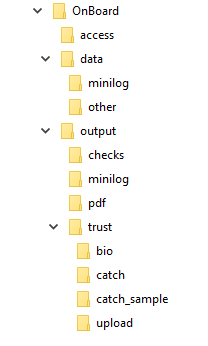

Figure 1: folders tree structure

# Collecting data

## Access file

The Access files are the main instrument to collect data onboard. To prevent creating very large files and for security reasons, it is good to store around 20 hauls in a .accdb file. When a .accdb reach the target, you can create another one.

### .accdb Structure

The Access is structured to host the data of a haul within a unique Table, called “calaX”, where X is the number of the haul (as from protocol). When a new haul “X” is processed, copy the table called “cala_template”, paste it and rename it as “calaX”.

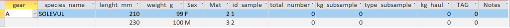

Figure 2: Example of the structure of the access file

### .accdb auto compilation general details

Auto compilation applies to some column of the access file. This mean that in the processing of the table, to empty cells is assigned the first available data that is found in the previous rows. When collecting data, for these column you need to specify the value just for the first observation, then you should fill the value again only when this change. These columns are:

- **gear**
- **species_name**
- **sex** (only for crustaceans)

### deal with cumulative data

Cases of cumulative data are **(i)** weight of all OTHER commercial species (*e.g.*: GOBINIG, LOPHIBUD); **(ii)** number of some OTHER commercial species (*e.g.*: MUREBRA, HEXATRU..).  
In case **(i)**, assign the cumulative weight in the column `weight_g` to just one specimen for which individual length is recorded and leave empty the other rows (as from Figure 3).  
In case **(ii)**, assign the cumulative weight in the column `weight_g` and the total number in the column `total_number`. In case of subsamples, refere to the sections below.

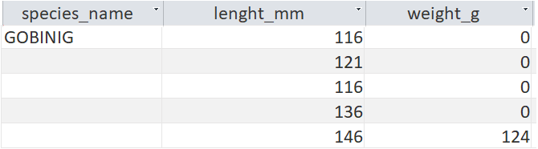

Figure 3: example of cumulative weight case i

### subsamples of target species

A typical case for subsample of target species is AEQUOPE, which usually occurs in large quantities and LFD is needed. In this case only a few individuals are measured to obtain the length structure, then it is needed to estimate total number (and sometimes total weight). Individuals that are processed for length and weight can be treated as any other target species. Regarding the other information needed to raise the values, you need to create a new record for the species (and gear) to store subsample data. There are two expected cases:

- **case 1: ALL individuals collected from the haul, subsample only for LFD** : weight of the subsample (constitued only by specimen of the species) in grams in the *weigth_g* field, total weight of the species in kg *kg_subsample*, “species” in column *type_subsample*.
- **case 2: first is collected a subsample from the haul (discard like), then ALL the individuals in the subsample are measured individually**: total weight of the species in grams in the *weigth_g* field, weight of the subsample (discard like) in kg *kg_subsample*, “haul” in column *type_subsample*, weight of the haul in the *kg_haul* filed.

### subsamples of non-target species (MUREBRA, HEXATRU, etc..)

A typical case for subsample of non-target species is MUREBRA. When it occurrs in large aggregations, total number (and sometimes total weight) are estimated from subsamples. To store information needed to raise the values, there are two expected cases:

- **case 1: ALL individuals collected from the haul, subsample only for estimating total number** : number of individuals in the subsample in the *total_number* field, weight of the subsample (constitued only by specimen of the species) in grams in the *weigth_g* field, total weight of the species in kg *kg_subsample*, “species” in column *type_subsample*.
- **case 2: first is collected a subsample from the haul (discard like), then ALL the individuals in the subsample are counted**: number of individuals in the subsample in the *total_number* field, total weight of the species in the subsample in grams in the *weigth_g* field, weight of the subsample (discard like) in kg *kg_subsample*, “haul” in column *type_subsample*, weight of the haul in the *kg_haul* filed.

## Minilog

Excel files retrieved from SeaStar should be stored in the folder ‘data/minilog’ and called as ‘minilogcode_shortdate’ (e.g.: K9478_1012’).

# Processing data

## process haul data

Data stored in the .accdb file are retrieved and handled by R scripts, located in the “R” folder. The required script is `workflow_access_v0`.

### process single hauls

To process single hauls, run the lines up to 15 and then please set the following parameters:

```
# set parameters
haul=22
db='test'
updateID='N'
area_sepia='D'
year=2022
area='ITA17'
```

When parameters are set, the data processing is pre-defined: you just have to run it without changing the parameters. The first step is the `function1`, which scope is to format the access table according to output standards. There is no need to see the output of this function. Just run it.

```
# function1 extract data from access db and format them
hauldata=function1(haul=haul,
                   db=db,
                   year=year)# extract and format data
```

When the function1 is done, you can proceed with the `function2`, which scope is to perform some checks. Checks done are plots that would be saved under the path ‘output/checks’

```
# function 2: perform checks
function2(xdat=hauldata,
          haul=haul)
```

`function3` scope is to format data according to trust format. Excel sheets are saved under the path ‘output/trust’.

```
# function 3: format data to trust format
trustdat=function3(xdat=hauldata[[1]],
                  haul=haul,
                  year = year,
                  weight_not_target = hauldata[[2]],
                  subsamples_target=hauldata[[3]],
                  catch_sample_disattivati = catch_sample_disattivati) # function 2
```

`function4` creates a pdf report and save it under the path ‘output/pdf’.

```
# function4: save PDF
function4(trustdat = trustdat,
          year=year,
          area = area,
          haul=haul)
```

### loop to process more hauls

To process more than one haul, you should care to properly fill in the ‘haul_order’ excel sheet (see input data section). After having loaded the haul summary, just run the loop represented below.

```
haul_summary=read_excel("data/haul_order.xlsx")
haul_summary=haul_summary[1:5,]

for(xhaul in 1:nrow(haul_summary)){


  # loop parameters
  haul=haul_summary[xhaul,]$haul
  db=haul_summary[xhaul,]$DB
  area=haul_summary[xhaul,]$country

  cat('processing haul no.', haul, '(', xhaul,'/', nrow(haul_summary),')' )

  # function1 extract data from access db and format them
  hauldata=function1(haul=haul,
                     db=db,
                     year=year)# extract and format data

  # function 2: perform checks
  function2(xdat=hauldata,
            haul=haul)

  # function 3: format data to trust format
  trustdat=function3(xdat=hauldata[[1]],
                     haul=haul,
                     year = year,
                     weight_not_target = hauldata[[2]],
                     subsamples_target=hauldata[[3]],
                     catch_sample_disattivati = catch_sample_disattivati) # function 2

  # function4: save PDF
  function4(trustdat = trustdat,
            year=year,
            area=area,
            haul=haul)


}
```

## Input data required by the code

This section explains the content of each file located in the data folder, and gives brief explanation of the file purpose.

### catch_sample_disattivati

This file controls formatting of trust templates. It indicates which samples (Station, Gear and SpecCode) should be indicated as “InUse” = FALSE in the catch sample files used as input data in trust.

| Station | Gear | SpecCode |
| --- | --- | --- |
| 11 | D | AEQUOPE |
| 7 | D | AEQUOPE |
| 55 | A | SOLEVUL |

### fishID

Store the *updated* serial number used to identify specimens for which detailed samples (otolit, genetic etc.) were taken. This number should refere to the *last* ID assigned to a specimen. The use of this file is controlled by the `updateID` parameter in the workflow_access_v0 file: if `updateID` is set equal to Y, the fishID file is used to assign IDs (when requested) and it is then updated. The columns refers to:

- **type**: not useful (to be removed)
- **code**: this is the alphanumeric part of the code to be assigned to specimens
- **fishID**: serial number referring to the *last* individual contained in the past records
- **haul**: not useful (to be removed)
- **species**: indicates which species belong to the code category. If need to add species, use : as separator and do not insert spaces.

Example of the fishID file structure

| type | code | fishID | haul | species |
| --- | --- | --- | --- | --- |
| ELAS | Elas | 202 | NA | RAJAAST:RAJACLA:RAJAMIR:TORPMAR |
| solea | SS | 6806 | NA | SOLEVUL:SOLEAEG |
| RHO | SR | 440 | NA | SCOHRHO |

### haul_order

Store the information associated with hauls. This file is used (1) when the data workflow is applied in loop; (2) by the minilog script. The columns refers to:

- **day**: day of the haul (yyyy-mm-dd)
- **haul**: number of the haul as from solemon protocol
- **id**: progressive number of the haul
- **note**: this space serve to write any kind of note, it is ignored by the code
- **inizio**: time of setting the net (hh:mm:ss)
- **fine**: time of hauling the net (hh:mm:ss)
- **verifica_shell**: this space serve to write additional notes, it is ignored by the code
- **DB**: indicates the name of the access database where the haul was recorder. Do not include ‘.accdb’ extension.
- **country**: indicates in which stratum the haul was performed. Available strata are ‘HRV’, ‘ITA17’, ‘SVN’

Example of the haul_order file structure

| day | haul | id | note | inizio | fine | verifica_shell | DB | country |
| --- | --- | --- | --- | --- | --- | --- | --- | --- |
| 2021-11-28 | 27 | 1 | CONTINUARE A RIVEDERE I NOMI SPECIE | 1899-12-31 08:17:00 | 1899-12-31 08:47:00 | 1 | part1 | ITA17 |
| 2021-11-28 | 28 | 2 | NA | 1899-12-31 10:11:00 | 1899-12-31 10:41:00 | 1 | part1 | ITA17 |
| 2021-11-28 | 29 | 3 | NA | 1899-12-31 11:55:00 | 1899-12-31 12:25:00 | 1 | part1 | ITA17 |

### lw_pars

Store the length-weigth parameters of target species. This file is used to reconstruct length (or weight) when it is not available in the recorded data. Example: shrimps where missi a part of the tail but have the head intact are suitable only for length measurement; fishes that were spoiled by the gear may be ok for weight but not measurables for length. The columns refers to:

- **species_name**: indicates which species belong to the code category (solemon code)
- **sex**: indicates the sex in case when sexual dimorphism in the growth is relevant. If dimorphism is not relevant, put combined parameter and write NA in this field
- **a**: parameter “a” for the length-weight relationship
- **b**: parameter “b” for the length-weight relationship
- **source**: source from where a and b were retrieved

Example of the lw_pars file structure

| species_name | sex | a | b | source |
| --- | --- | --- | --- | --- |
| SOLEVUL | NA | 0.00460 | 3.11 | benchmark_assessment |
| MULLBAR | NA | 0.00871 | 3.09 | fishbase |
| RAJACLA | NA | 0.00269 | 3.23 | fishbase |

### maturity_stages

Store the code of the maturity scales for target species. This file is used to format input files for trust.

- **SPECIES**: indicates which species belong to the code category (solemon code)
- **SEX**: indicates the sex
- **SCALE**: include the alphanumeric part of the maturity scale code

Example of the maturity_stages file structure

| SPECIES | SEX | SCALE |
| --- | --- | --- |
| MELIKER | F | MEDPF |
| MERLMER | F | MEDFI |
| MERLMER | M | MEDFI |

### solemon_TB

This is just the TB file updated to 2021, as stored in trust. It serves to perform some checks and it should not be modified. Preview not shown.

### species_list

Example of the species_list file structure

| Species | Medits | Sp_Subcat | Len_Class | Notes |
| --- | --- | --- | --- | --- |
| Aaptos aaptos | AAPTAAP | E | NA | NA |
| Abra prismatica | ABRAPRI | E | NA | NA |
| Abra sp | ABRASPP | E | NA | NA |

### target_species

Contains the species that are target for the survey (individual length and weight) and the molluscs for which only total weight and total number are needed.

Example of the target_species file structure

| species_name | target |
| --- | --- |
| SOLEVUL | 1 |
| SOLEAEG | 1 |
| PLATFLE | 1 |